# midterm2

Charles Yang 510 636 138

10/29/2021

1. Concept Review

a. Compenent (a) is our least squares estimate. (b) is the ellipse of possible values of the estimate once a penalty term is applied. (c) and (d) are the constraints that Lasso and Ridge regressions place on the lease squares estimate + penalty. Because Lasso's constraint involves an absolute value, and therefore a diamond shape, it becomes possible for the ellipse of beta values to lie on an axis, setting a coefficient to zero. The circle constraint of ridge makes it impossible, but it can get very close.

b. False. QDA can have different covariance matrices, whereas Bayes cannot.

c. False. Those selection criteria apply penalties for the number of predictors in a model, so it doesn't make sense to use them to compare models of the same size. When the models are the same size, we can look at r^2 or test MSE, depending on our application.

d. I disagree. Cross validation should be done on the training set, not all data. Test set should not be touched until we have a model ready to compute test MSE with.

```r
heart = read.table("http://www-stat.stanford.edu/~tibs/ElemStatLearn/datasets/SAheart.data",sep=",",head=T,row.names=1)
n = nrow(heart)
```

```r
logit.fit = glm(chd~age, data=heart, family='binomial')
x = data.frame(age=50)
logit50Prob = predict(logit.fit, x, type='response')
logit50Prob
```

```
##         1
## 0.4215756
```

```r
B = 2000
logit50Probs = rep(0,B)
for(b in 1:B){
  bootindex = sample(1:n,n,replace=TRUE)
  bootsample = heart[bootindex,]

  fit = glm(chd~age, data=bootsample, family='binomial')
  logit50Probs[b] = predict(fit, x, type='response')
}

bootmean = mean(logit50Probs)
sqrt(sum((logit50Probs-bootmean)^2)/(B-1))
```

```
## [1] 0.02668876
```

2a. Bootstrap & Logit

a. See code

b. 0.4215756

```r
test = heart[1:100,-5]
train = heart[-(1:100),-5]
```

```r
K = c(1, 3, 5, 7, 9)
standardizedX = scale(train[,-9])

misclassifications = matrix(NA, 5, nrow(train))

for(i in 1:5){
  k = K[i]
  for(j in 1:nrow(train)) {
    loo = j

    testX = standardizedX[loo,]
    trainX = standardizedX[-loo,]

    testY = train$chd[loo]
    trainY = train$chd[-loo]

    knn.pred = knn(trainX, testX, trainY, k=k)
    misclassifications[i,j] = testY != knn.pred
  }
}
cvMisclassification = apply(misclassifications,1,mean)
paste0("Best k is ",K[which.min(cvMisclassification)])
```

```
## [1] "Best k is 9"
```

```r
train.X = standardizedX
train.Y = train$chd
test.X = scale(test[,-9])
knn.pred = knn(train.X, test.X, train.Y, k=9)

tab = table(knn.pred, test$chd)
tab
```

```
##
## knn.pred  0  1
##        0 54 26
##        1  7 13
```

```r
mean(test$chd != knn.pred)
```

```
## [1] 0.33
```

```r
mean(test$chd != 0)
```

```
## [1] 0.39
```

2b. KNN

a. Best k is 9

b. See output above for confusion matrix and misclassification rate

c. We get 0.39. It's slightly higher than what we got in (b), but suprisingly not higher than I thought it would be.

Extra Credit:

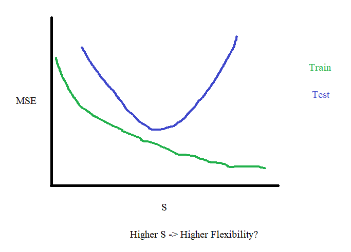